# Pratical Machine Learning Project

JP

September 12, 2016

## Introduction

In this exercise I examine data from personal activity sensors to create an statistical model to predict which exercise was perfomed by a user at a determined time.

The results from this analysis can provide guidance to the each particular user as to which exercise is more favorable to do.

The data is provide by the Practical Machine Learning Class in Coursera. There are two sets, on with actual data from different users (pml-training.csv) and a smaller subset to apply the model on (pml-testing.csv).

Here, I upload the data from the respective urls, clean it, and set it ready for model construction. Then compare different models and decide which model to use in the predictions. Finally, present the prediction for each of the users in the testing data set.

# Data upload and cleaning

I downloaded the data directly from the websites using the urls provided in the instructions. The was loaded in r converting all missing data into NA. Next, I checked to make sure all the names in each data set correspond, and remove columns with no data, including the first 7 columns.

# Check and remove (if necesary) columns with no-variability:

Now I used the check for zero variance function in the variables revealing this data has 0 variables with no variability, therefore there is no need to remove any of additional variable.

# Detecting the more relevant variables

Using the random forest method I detected the 5 most relevant variables of the analysis.

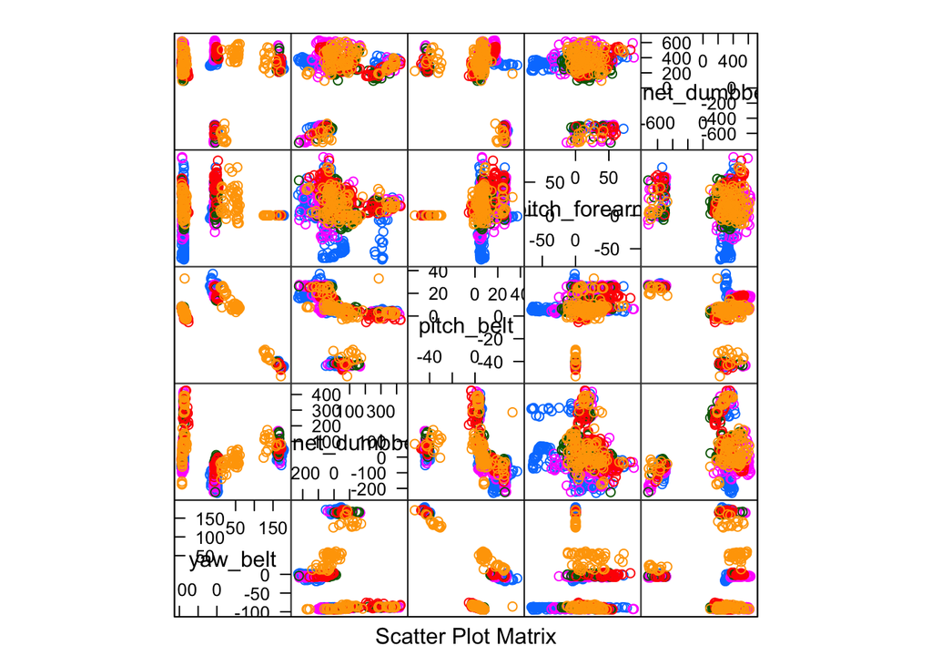

These variables are: yaw_belt, magnet_dumbbell_z, pitch_belt, pitch_forearm, magnet_dumbbell_y. None of these important features shows a linear relation with eachother.

# Model selection

I decided to built three training sets with a different method (KNN, Random forest and Rpart) and determine which had a higher accuracy.

The accuracies are:0.9133361 for KNN, 0.9914356 for Random Forest, and 0.4981648 for Rpart. With the highest being that of the Random Forest Model.

The error in the Random Forest model is the lowest.

# Predictions

The predictions for the 20 users in the testing data set are: B, A, B, A, A, E, D, B, A, A, B, C, B, A, E, E, A, B, B, B